# MATH5741M: Statistical Theory and Methods

## Solution to Exercise 5

```r
mu <- mean(galaxies$GlobularClusters)
sigma <- sd(galaxies$GlobularClusters)

ks.test(x =  galaxies$GlobularClusters, y = "pnorm", mean = mu, sd = sigma)
```

```
##
##  One-sample Kolmogorov-Smirnov test
##
## data:  galaxies$GlobularClusters
## D = 0.29856, p-value = 0.0006562
## alternative hypothesis: two-sided
```

The results suggest that velocity dispersion (which produced a large p-value) is normally distributed but that the number of globular clusters (which produced a small p-value) is not. This makes sense given the plots that we saw in the previous sections.

## Solution to Exercise 6

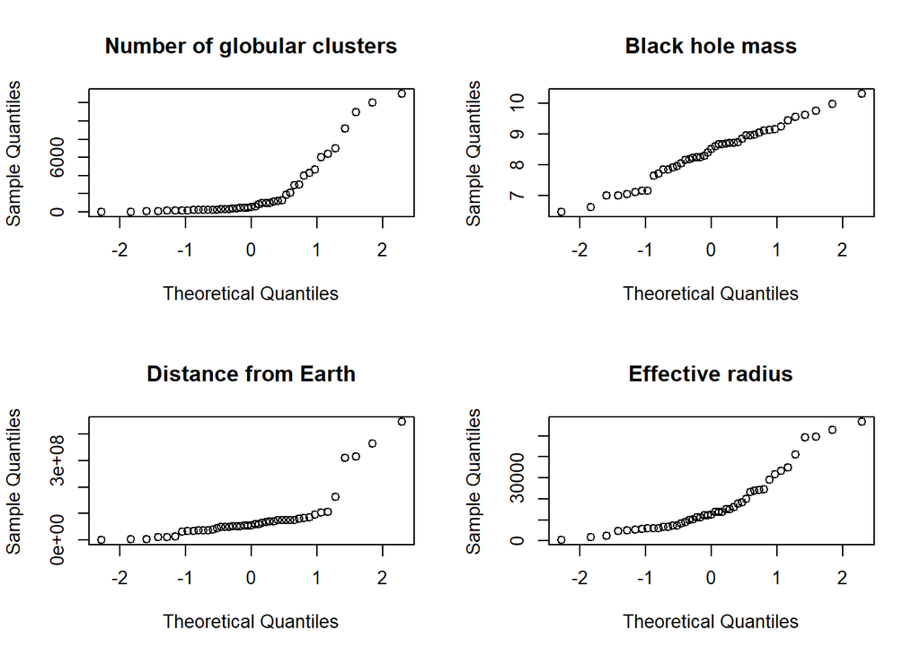

Figure 2: QQ plots to check normality of four different variables.

```
##
##  Shapiro-Wilk normality test
##
## data:  galaxies$GlobularClusters
## W = 0.67534, p-value = 1.059e-08
```

```
##
##  Shapiro-Wilk normality test
##
## data:  galaxies$BlackHoleMass
## W = 0.98105, p-value = 0.6622
```

```
##
##  Shapiro-Wilk normality test
##
## data:  galaxies$Distance
## W = 0.63296, p-value = 2.287e-09
```

```
##
##  Shapiro-Wilk normality test
##
## data:  galaxies$Eradius
## W = 0.85008, p-value = 3.678e-05
```

Again, it appears that the normality assumption for velocity dispersion is justified. The quantile plot supports this assumption, and the Shapiro-Wilk test fails to reject it. Out of the four other four variables, only black hole mass appears to be normally distributed. The others show fairly clear curvature in the quantile plots, suggesting some skew in their distributions. The hypothesis test results support these conclusions, since the p-values are tiny for all but black hole mass.

## Solution to Exercise 7

```r
library(nortest)

pearson.test(galaxies$GlobularClusters)
```

```
##
##  Pearson chi-square normality test
##
## data:  galaxies$GlobularClusters
## P = 84.556, p-value = 1.616e-15
```

```r
pearson.test(galaxies$BlackHoleMass)
```

```
##
##  Pearson chi-square normality test
##
## data:  galaxies$BlackHoleMass
## P = 9.8889, p-value = 0.195
```

```r
pearson.test(galaxies$Distance)
```

```
##
##  Pearson chi-square normality test
##
## data:  galaxies$Distance
## P = 53.444, p-value = 3.029e-09
```

```r
pearson.test(galaxies$Eradius)
```

```
##
##  Pearson chi-square normality test
##
## data:  galaxies$Eradius
## P = 23.667, p-value = 0.001304
```

As in previous sections, it appears that only black hole mass and velocity dispersion are normally distributed.